# Ecological Genomics Notes

P. Alexander Burnham

January 23, 2017

# January 23, 2017:

## Info Update: Mellisa

- Advantages in Seq tech.
- Ranage of applications:
  - WGS (whole genome sequencing)
  - RNAseq (seqencing RNA conveted to cDNA)
  - Targeted caputure seq. (string of probes mixed with sample, pulls immune related genes from organisim and seq just those)
  - Chipseq (chromatin imunoprecipitation seq, recognizezes and antibody and puls out all DNA bound to that portein)

**Why one or the other?**

Genetic variation

```
  - phenotypes
```

number of samples

```
  - population
  - individual
  - comparitive studies
  - model or note
```

Demographic history

Adaptive geneitc varaitin

gene expression car.

length of reads

number of reads

distribution

Reads:

```
  - short = 50bp
  - long 100 bp, 150 bp, 300 bp (miseq)
  - 10,000-60,000bp = SMRT
```

Single vs. paired end

- General library Prep. Workflow
  - extraction (DNA, RNA -> to cDNA)
  - fragment sample
  - ligate adaptors (indvidual barcodes)
  - add seq. adaptors

  *Reduced Rep*
  - RNA -> coding
  - GBS/RAD-seq
  - near restriciton sites
- Sequencing-by-synthesis (SBS)
  - bridge amp
  - cluster gen.
  - labeled dNTP (ATCG)
- Other Technologies
- Learning Activity

**Human Genome Project (2001-2003)**

```
  - ABI = Sanger
  - 15 years
  - 1 geneome (one person)
  - $3 billion
```

Uses PCR and sequences broken by faulty base pairs to work backwards

**2014 X-Ten releases**

```
  - Hiseq by Illumina (look up video of how it works)
  - 1 day
  - 45 whole genomes
  - $1000 bucks each
```

Sheet of glass with 8 lanes with flow cells…(look up)

**Take home messages**

- Likely using Illumina seq. (just library tech. changes) usually SBS
- adaptors are markers (barcodes) used to identify samples during sequencing
  - first thing that’s sample and gives ID barcode = seq adaptor
  - alago is a sequence of DNA that is attatched to plate binds to sample
- Model vs. non Model:
  - short reads (assembly to create long sequnce based on short reads that shift)
  - denavo assembly -> computer program (added variability with mixed sample)
  - 15% error for SMRT can be reduced to less than 1 with repeated passes
  - illumina is much smaller but more accurate (0.05% error)
  - combine the two to have a higher degree of confidnece

## Paper Discussion:

### Three advances in biology:

- Modern Synthesis (evolution (Darwin) and population genetics (Mendel))
- Watson and Crick (molecular biology DNA)
- Omics Era (genomics, preteomics etc.)

### What do we think about this?

- Phylogenies -> reducing error bars or reshaping question?
- Do you throw out experimetnal design and scientific method for large scale shot gun blast sequencing? - > can still be used to do hypothesis driven science, but also something to be said for sending a teleoscope into deep space.
- Most journals and funding sources require all seq data be made public - leeds to a storage space issure -> genbank ran out of space and needed emergency funding from congress.
- data are not reviewed very well some gen bank sequences are kinda rough
- reference genomes are a sample size of 1 so it might not be representative

On Wednesday two papers to talk about:

1. where do genomics data have limitations and why we use them
2. discussion leaders (sign up via blackboard)
3. next week talk about some of library preps (four of them) four differnt update people

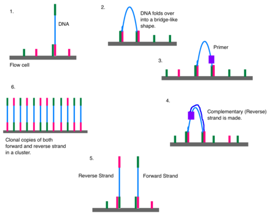

Illumina Sequencing

# January 25, 2017:

## Info Update: Steve

### Outline:

- What are QTN
- Quantitative Gentics
  - theory of adaptive traits
    - V<sub>a</sub>
    - h<sup>2</sup>
- Methods
  - linkage mapping
  - GWAS
  - selection scans

### Notes on topics in outline:

- QTN = “quantitative trait necleotides”
  - Flowering times (quantitative traits)
  - Flower color (more descrete - mendalian major effects traits)
  - THermal tolerance
  - venom potancy
  - defense compounds
  - toxin tolerance
  - drought tolerance
  - altitiude tolerance

**Looking at haldane and fishers work on Quant genetics:**
- addative effect at each locus and addative effect average our Additive genetic variance or V<sub>a</sub>
- the additive portion of the addedative variance or phenotypic variance equals heritiability
$$(V_a/V_p = h^2)$$
- the differnce between pheotypic variance between loci is addative effect and average out to average affect which is usually a linear functiion
- most populations are at the value of trait where fitness is max (local addpatition) - mutation with small effect on trait (fisher thought most important mutation 50% of being beneficial)
- large effect mutation -> tend not to be selected -> to extreme and usually cause problems - best traits climb to the fitness peak through small incremental steps

## Three main methods:

### 1) QTL mapping (linkage mapping) - assumed that two parents are homozygous (for continuos trats) - F<sub>1</sub> is heterozygous but no recombinance - mate the F<sub>1</sub> generation and get one generation of recombination for these traits - **The Idea of QTL** use markers linked to chromosomes, crossing (over many generations)

```
linkage
|           QTN
|             o
|         o       o
|       o           o
|   o                 o
|o                        o
--------|-----------|-----------
0                             5
          Chromsome
```

### 2) GWAS:

$$y_{trait} = mu_{intercept} + beta_{effectsize} * SNP_i + covariates_{population size}$$

collect data run regressions (millions)

**Manhatten plot

```
log_p
|                       .
|                       .
|                       ..
|                     ....
|.....  ......  ..........
|  ...............  ........
--------------------------------
1    2      3      4     5     6
```

### 3) Selection SCANS (based ons selection sweeps):

```
x= SNPs
selction favors mutation next to O

pop1                                  pop1
________x_________                  _xO__________________

___x______x______x                  _xO__________________
                          time
_xO__________________     ------>   _xO__________________

______________x____                 _xO__________________


pop2
________x_________

___x______x______

_xO__________________

______________x____


- lose variation as everything favors the mutation
- diversity is higher in pop 2
- FST is populations struction high FST will be for pop2 low for pop 1 after selction
```

- we study the few large effect size mutations for QTL and QTN that we study because they are easy to find
- majority are small but hard to find

## PAPER DISCUSSION:

forward vs reverse approach

apply scientific method and don’t assume that evrything is representing the sample of arge mutations we have mostly been studying

1. large effect allele mutation (mendelian)
2. basic theory in terms of gen. theoary neither requires or predicts the importance of large mutations
3. making assumption that the little parts we find act the same way the big parts act the sam way and thats probably not true

They will argue that there will be knowledge to found using this information

## DISCUSION OF GROUP PROJECT

### Notes on Seastar Wasting Disease:

**BACKGROUND ON DISEASE**

- High mortaility (between 70-100%)
- many species impacted (not species specific)
- loss of legs withing hours or days, turns inside out!
- turn into goo
- Alaska to Baha
- First report in 2012, less severe currently (reported in the 1970s and 80s in isolation)
- study (Hewson et al., 2014) linked Densovirus implicated but not very confidnet
- potentially something in microbiom can lower host immunity and allow for opportunistic infection by pathogen
- [Seastar Disease Outbreak Distribution](http://data.piscoweb.org/marine1/seastardisease.html)

**INFO ON WHAT DATA WE HAVE**

- focusing on *Pisaster ercraceous*
- RNA extractions and polly a tail and sequenced mRNA on 3 illumina hiseq lanes
- also pulled our ribosmal 16s structure
- none of samples pos for densavirus (qPCR) positive control
- DNA virus
- is it cyclical
  - 1. never been so extreme before
  - 2. do go through booms and busts though
- All arrived healthy
- put into aquaria with artifial seawater (kept at 12<sup>o</sup>C)
- From same site
- were no infected; some developed SWD on there own
- first and only time course study of this kind

## Hypothesis ideas:

### My idea: (Envirnomental Componant)

- Intertidal VS Subtidal
  - genetic differences (local adapt.) related to suseptabilty
  - gene expression (immune related genes higher in SUB group)

### Other ideas:

- Resistance genes (stayed healthy or recovered)
- w/in Intertidal -> gen. differences between three groups
- both groups, Microbiome -> H vs S (differences (yes or no))
- Microbiome through time
- h<sup>2</sup> of microbiome
  - day as replicate
  - relatedness VS microbiome trait
- immune related genes (Sam)
  - what kind of pathogen based which genes are expressed
  - which are the immune relatedness genes (conserved in other species)
  - potential problems -> viruses that are opportunistic and enter at tail end of infection and immune repsonse genes still expressed (confounded?)

# January 30, 2017:

## Info Update: Group

**2 ideas i’m interested in**

- Intertidal VS Subtidal
  - genetic differences (local adapt.) related to suseptabilty
  - gene expression (immune related genes higher in SUB group)
  - same population but handeling was different (intertidal was more stressful)
  - gene expression differences
  - microbiome differences
- Immune-related gene expression
  - reverse pathology
  - looking for specific classes of genes
  - a-priori tests for resitance genes (compaire indv. that got sick to healthy)
  - looking at the S -> H transition

**To Do:** Team Sherlock

Chose reverse gene exression

One page proposal for ideas for our project (1 per group) for next monday. Use handout as outline. Word and email. For wednesday, bioblitz (library prep types)